# Eric_Hirsch_624_Project_1

### KWH

**1. Examine the data**

The data has both a missing value and an outlier. We use Arima to interpolate both. We might imagine that the outlier is a typo (and then we might just add a 0 to the end) but we have no other evidence to suggest this.

The variance appears to increase over time so we will apply a boxcox transformation.

```
##   CaseSequence     YYYY-MMM              KWH
##  Min.   :733.0   Length:192         Min.   :  770523
##  1st Qu.:780.8   Class :character   1st Qu.: 5429912
##  Median :828.5   Mode  :character   Median : 6283324
##  Mean   :828.5                      Mean   : 6502475
##  3rd Qu.:876.2                      3rd Qu.: 7620524
##  Max.   :924.0                      Max.   :10655730
##                                     NA's   :1
```

```
## tbl_ts [192 × 3] (S3: tbl_ts/tbl_df/tbl/data.frame)
##  $ CaseSequence: num [1:192] 733 734 735 736 737 738 739 740 741 742 ...
##  $ Month       : mth [1:192] 1998 Jan, 1998 Feb, 1998 Mar, 1998 Apr, 1998 May, 1998 Jun...
##  $ KWH         : num [1:192] 6862583 5838198 5420658 5010364 4665377 ...
##  - attr(*, "key")= tibble [1 × 1] (S3: tbl_df/tbl/data.frame)
##   ..$ .rows: list<int> [1:1]
##   .. ..$ : int [1:192] 1 2 3 4 5 6 7 8 9 10 ...
##   .. ..@ ptype: int(0)
##  - attr(*, "index")= chr "Month"
##   ..- attr(*, "ordered")= logi TRUE
##  - attr(*, "index2")= chr "Month"
##  - attr(*, "interval")= interval [1:1] 1M
##   ..@ .regular: logi TRUE
```

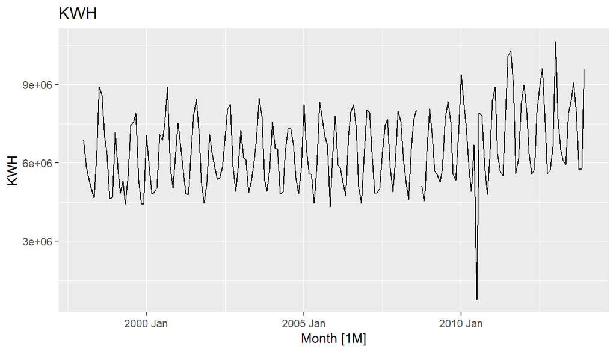

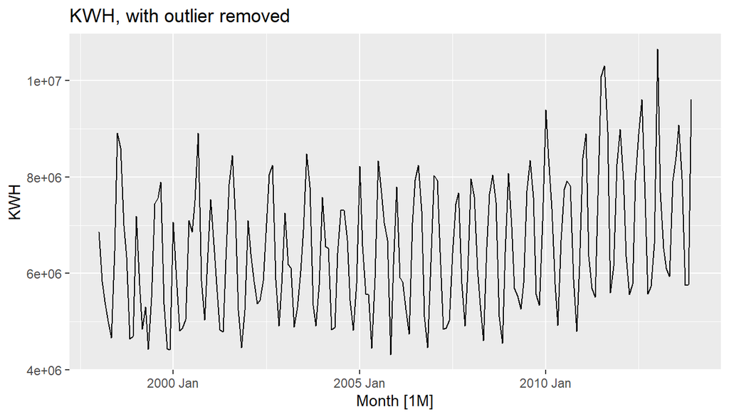

**2. We will train using various methods on 75% of the data.**

This time instead of an additive ETS model we use a multiplicative to capture the exponential trend.

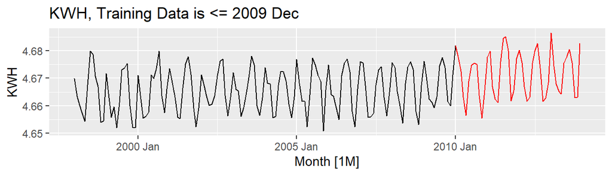

**a. Residual plots for each of the models**

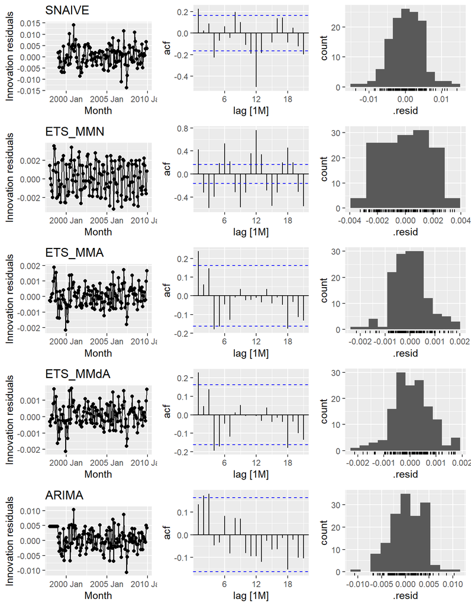

**b. RMSE and forecasts**

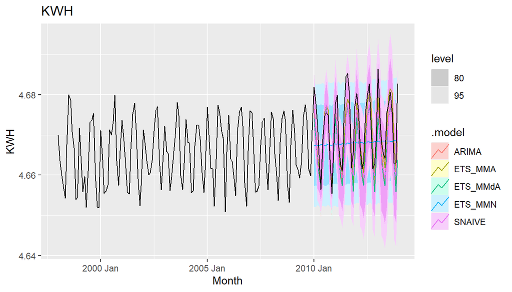

```
## # A tibble: 5 × 10
##   .model   .type      ME    RMSE     MAE    MPE   MAPE  MASE RMSSE  ACF1
##   <chr>    <chr>   <dbl>   <dbl>   <dbl>  <dbl>  <dbl> <dbl> <dbl> <dbl>
## 1 ARIMA    Test  0.00397 0.00548 0.00430 0.0849 0.0920   NaN   NaN 0.285
## 2 ETS_MMA  Test  0.00207 0.00476 0.00362 0.0442 0.0773   NaN   NaN 0.327
## 3 ETS_MMdA Test  0.00503 0.00660 0.00529 0.108  0.113    NaN   NaN 0.317
## 4 ETS_MMN  Test  0.00364 0.00894 0.00774 0.0775 0.166    NaN   NaN 0.399
## 5 SNAIVE   Test  0.00399 0.00584 0.00473 0.0853 0.101    NaN   NaN 0.247
```

**3. Forecast using the best model.**

ETS_MMA has the lowest RMSE and the residuals, with a few small exceptions in the acf plot, look like white noise. However, the ARIMA model also has a low RMSE and more normally distributed residuals, so we’ll look at both.

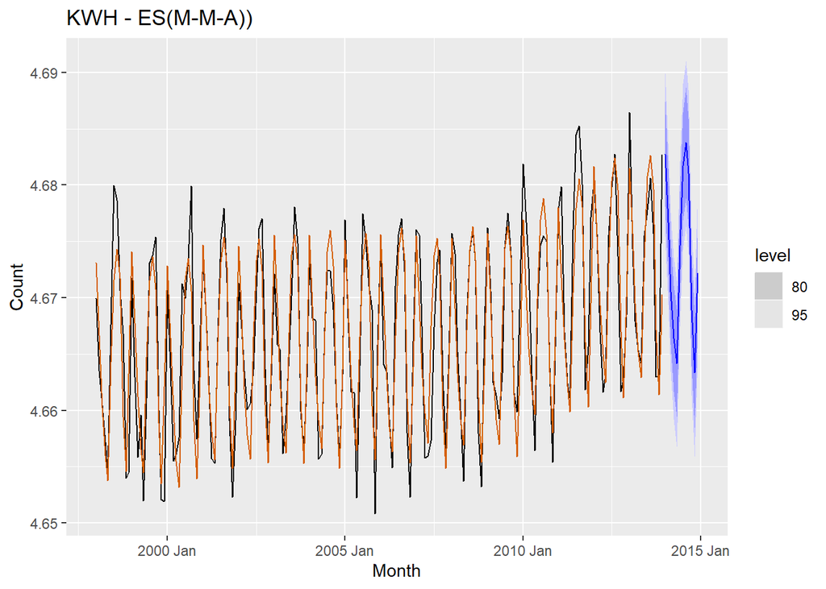

```
## Series: KWH
## Model: ETS(M,M,A)
##   Smoothing parameters:
##     alpha = 0.07679262
##     beta  = 0.00132528
##     gamma = 0.0001006672
##
##   Initial states:
##      l[0]     b[0]         s[0]       s[-1]        s[-2]       s[-3]
##  4.663678 1.000005 -0.002095888 -0.01078722 -0.005287552 0.006963209
##        s[-4]       s[-5]        s[-6]        s[-7]        s[-8]       s[-9]
##  0.009873606 0.007849855 0.0008124751 -0.009611188 -0.007265691 -0.00301425
##       s[-10]      s[-11]
##  0.003171756 0.009390889
##
##   sigma^2:  0
##
##       AIC      AICc       BIC
## -1125.043 -1121.526 -1069.666
```

```
## [1] 92904482
```

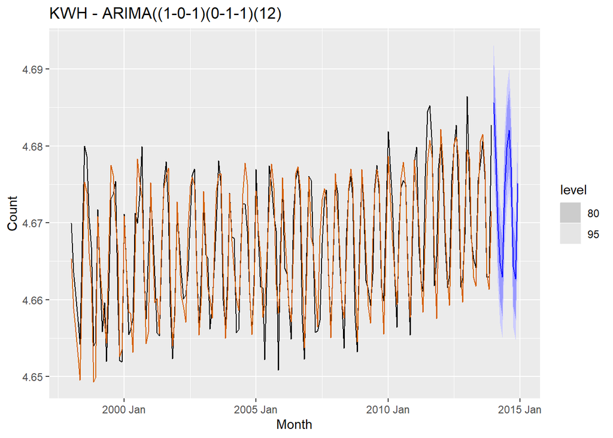

```
## Series: KWH
## Model: ARIMA(1,0,1)(0,1,1)[12] w/ drift
##
## Coefficients:
##          ar1      ma1     sma1  constant
##       0.5318  -0.2706  -0.7165     3e-04
## s.e.  0.2434   0.2813   0.0646     1e-04
##
## sigma^2 estimated as 1.459e-05:  log likelihood=754.03
## AIC=-1498.06   AICc=-1497.72   BIC=-1482.1
```

```
## [1] 91392876
```

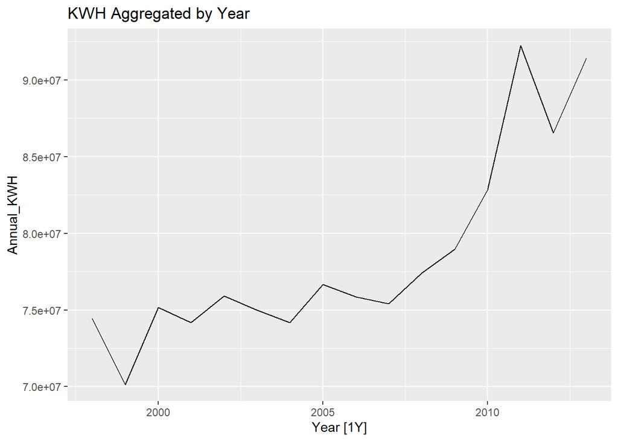